# ggplot2::workshop(…)

#### Tufts Friedman Symposium 2021

##### written by: M.A. Hartwick

## Set up the environment

##### (check if tidyverse installed)

```r
packages <- c("tidyverse", "skimr", "RColorBrewer")
install.packages(setdiff(packages, rownames(installed.packages())))
```

```r
library(tidyverse)
library(skimr)
library(RColorBrewer)
search()
```

```
##  [1] ".GlobalEnv"           "package:RColorBrewer" "package:skimr"
##  [4] "package:forcats"      "package:stringr"      "package:dplyr"
##  [7] "package:purrr"        "package:readr"        "package:tidyr"
## [10] "package:tibble"       "package:ggplot2"      "package:tidyverse"
## [13] "package:stats"        "package:graphics"     "package:grDevices"
## [16] "package:utils"        "package:datasets"     "package:methods"
## [19] "Autoloads"            "package:base"
```

## 1. Data

```r
iris[1:20,]
```

|  | Sepal.Length | Sepal.Width | Petal.Length | Petal.Width | Species |
| --- | --- | --- | --- | --- | --- |
| 1 | 5.1 | 3.5 | 1.4 | 0.2 | setosa |
| 2 | 4.9 | 3.0 | 1.4 | 0.2 | setosa |
| 3 | 4.7 | 3.2 | 1.3 | 0.2 | setosa |
| 4 | 4.6 | 3.1 | 1.5 | 0.2 | setosa |
| 5 | 5.0 | 3.6 | 1.4 | 0.2 | setosa |
| 6 | 5.4 | 3.9 | 1.7 | 0.4 | setosa |
| 7 | 4.6 | 3.4 | 1.4 | 0.3 | setosa |
| 8 | 5.0 | 3.4 | 1.5 | 0.2 | setosa |
| 9 | 4.4 | 2.9 | 1.4 | 0.2 | setosa |
| 10 | 4.9 | 3.1 | 1.5 | 0.1 | setosa |

[output cut: 10 more lines]

### Data Structure (tidyverse)

```r
iris %>%
  skimr::skim()
```

Data summary

| Name | Piped data |
| --- | --- |
| Number of rows | 150 |
| Number of columns | 5 |
| _______________________ |  |
| Column type frequency: |  |
| factor | 1 |
| numeric | 4 |
| ________________________ |  |
| Group variables | None |

**Variable type: factor**

| skim_variable | n_missing | complete_rate | ordered | n_unique | top_counts |
| --- | --- | --- | --- | --- | --- |
| Species | 0 | 1 | FALSE | 3 | set: 50, ver: 50, vir: 50 |

**Variable type: numeric**

| skim_variable | n_missing | complete_rate | mean | sd | p0 | p25 | p50 | p75 | p100 | hist |
| --- | --- | --- | --- | --- | --- | --- | --- | --- | --- | --- |
| Sepal.Length | 0 | 1 | 5.84 | 0.83 | 4.3 | 5.1 | 5.80 | 6.4 | 7.9 | ▆▇▇▅▂ |
| Sepal.Width | 0 | 1 | 3.06 | 0.44 | 2.0 | 2.8 | 3.00 | 3.3 | 4.4 | ▁▆▇▂▁ |
| Petal.Length | 0 | 1 | 3.76 | 1.77 | 1.0 | 1.6 | 4.35 | 5.1 | 6.9 | ▇▁▆▇▂ |
| Petal.Width | 0 | 1 | 1.20 | 0.76 | 0.1 | 0.3 | 1.30 | 1.8 | 2.5 | ▇▁▇▅▃ |

### tidyverse

#### (data cleaning)

```r
set.seed(100)
iris_clean <- iris %>%
  mutate(Trial = sample(3, n(), replace = TRUE))
```

```r
iris_clean %>% skim()
```

Data summary

| Name | Piped data |
| --- | --- |
| Number of rows | 150 |
| Number of columns | 6 |
| _______________________ |  |
| Column type frequency: |  |
| factor | 1 |
| numeric | 5 |
| ________________________ |  |
| Group variables | None |

**Variable type: factor**

| skim_variable | n_missing | complete_rate | ordered | n_unique | top_counts |
| --- | --- | --- | --- | --- | --- |
| Species | 0 | 1 | FALSE | 3 | set: 50, ver: 50, vir: 50 |

**Variable type: numeric**

| skim_variable | n_missing | complete_rate | mean | sd | p0 | p25 | p50 | p75 | p100 | hist |
| --- | --- | --- | --- | --- | --- | --- | --- | --- | --- | --- |
| Sepal.Length | 0 | 1 | 5.84 | 0.83 | 4.3 | 5.10 | 5.80 | 6.4 | 7.9 | ▆▇▇▅▂ |
| Sepal.Width | 0 | 1 | 3.06 | 0.44 | 2.0 | 2.80 | 3.00 | 3.3 | 4.4 | ▁▆▇▂▁ |
| Petal.Length | 0 | 1 | 3.76 | 1.77 | 1.0 | 1.60 | 4.35 | 5.1 | 6.9 | ▇▁▆▇▂ |
| Petal.Width | 0 | 1 | 1.20 | 0.76 | 0.1 | 0.30 | 1.30 | 1.8 | 2.5 | ▇▁▇▅▃ |
| Trial | 0 | 1 | 2.13 | 0.79 | 1.0 | 1.25 | 2.00 | 3.0 | 3.0 | ▅▁▇▁▇ |

## 2. Function

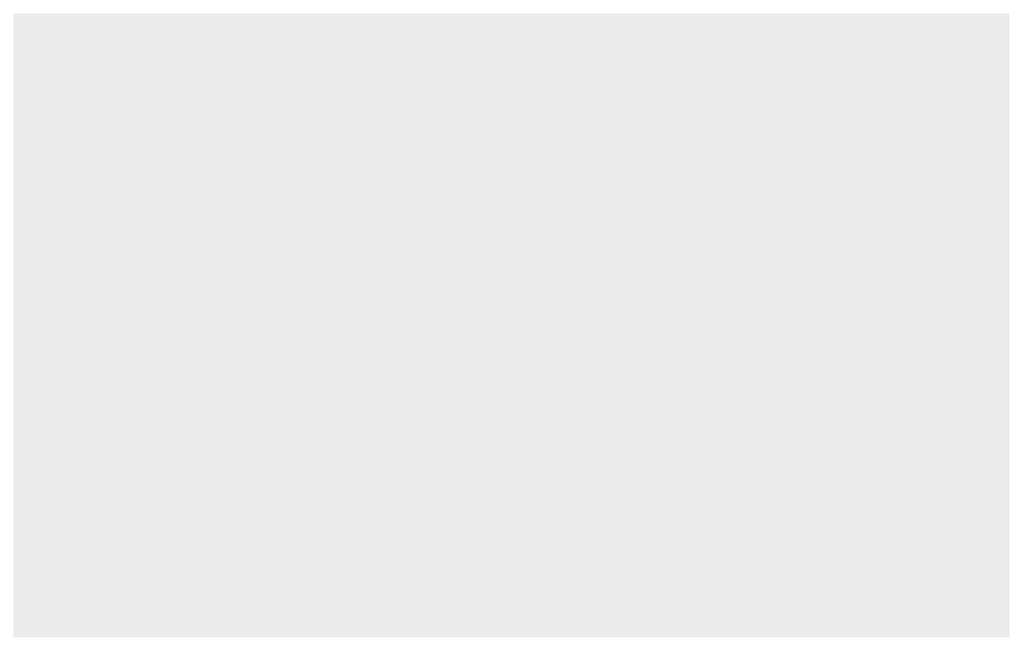

```r
iris_clean %>%
  ggplot()
```

## 3. Coordinates

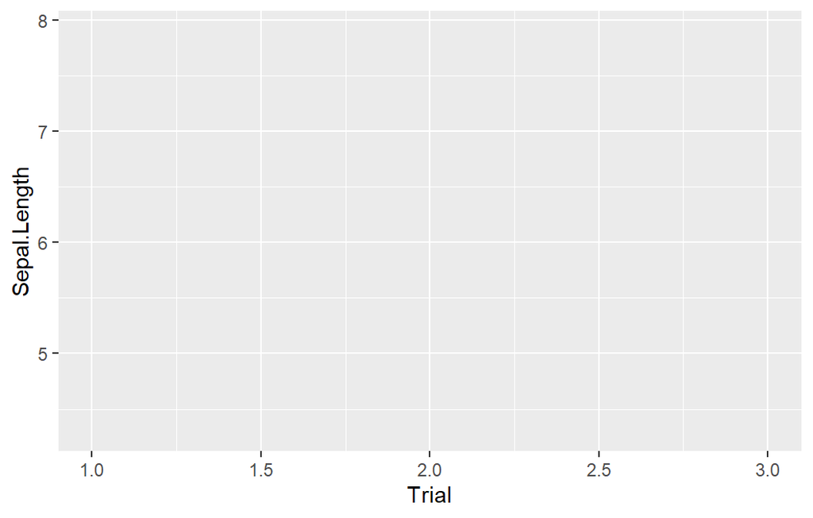

```r
iris_clean %>%
  ggplot(.,aes(x = Trial, y = Sepal.Length ))
```

## 4. Mapping

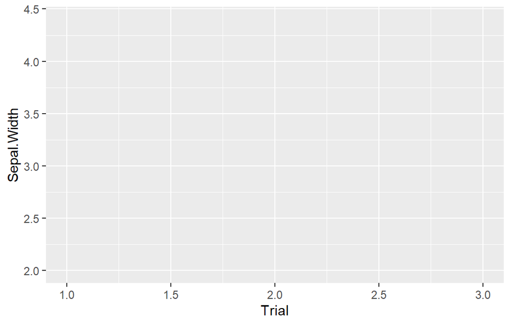

```r
iris_clean %>%
  ggplot(.,aes(x = Trial, y = Sepal.Width, color = Species))
```

## 5. Geometries

#### geom_histogram(…), geom_point(…), geom_bar(…), geom_col(…)

##### - geom_histogram(…) is a count geom, so only takes one coordinate

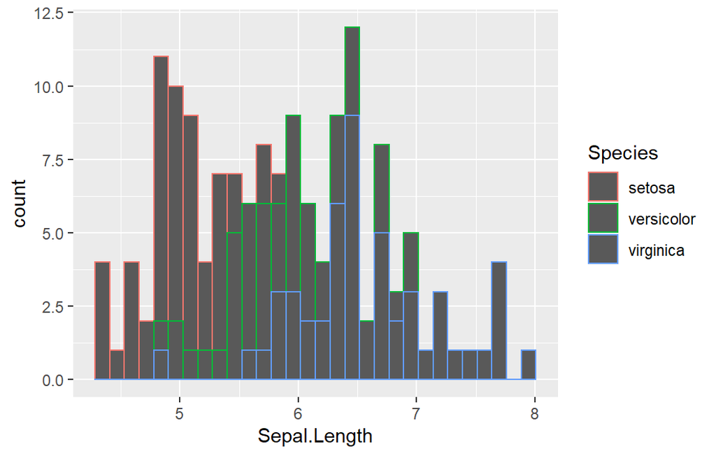

```r
iris_clean %>%
  ggplot(.,aes(x = Sepal.Length, color = Species)) +
  geom_histogram()
```

##### - color sets the outline here, what happens if we try fill instead?

##### - what happens when we specify bin size?

##### - where should that argument go?

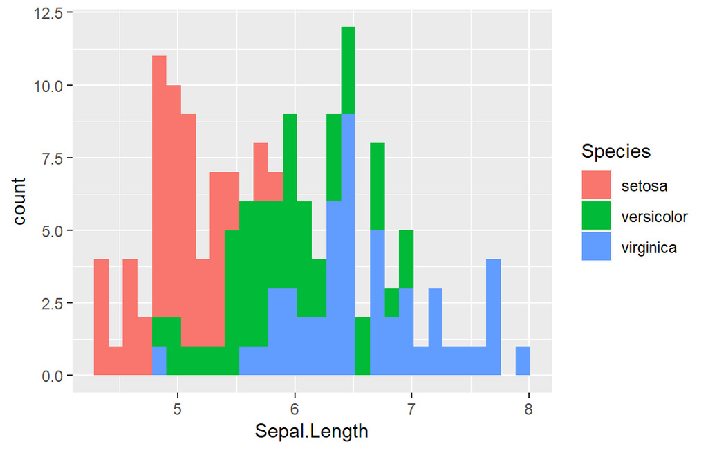

```r
iris_clean %>%
  ggplot(.,aes(x = Sepal.Length, fill = Species)) +
  geom_histogram()
```

##### - The geom ‘fill’ is specified

##### - Add an outline and transparency outside the mapping.

##### - Could we specify the fill aesthetic inside the geom_histogram?, how?

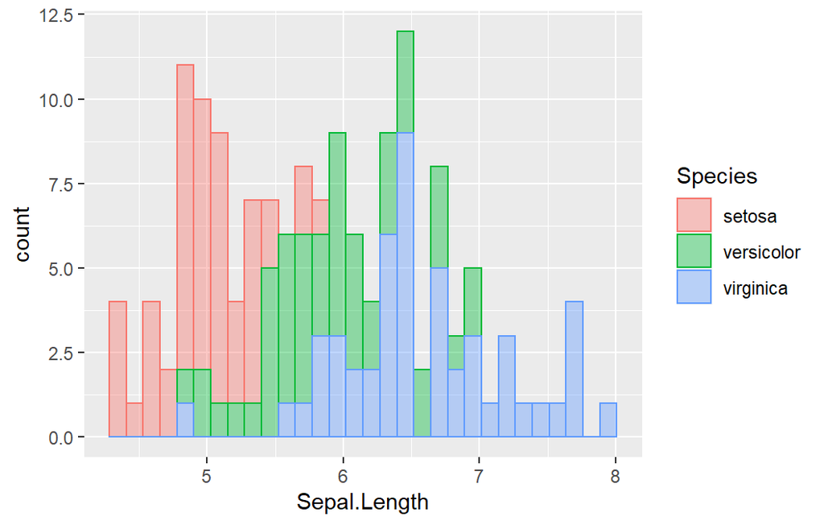

```r
iris_clean %>%
  ggplot(.,aes(x = Sepal.Length, fill = Species)) +
  geom_histogram(aes(color = Species), alpha = 0.4)
```

##### - Try out geom_point with an x and y coordinate.

##### - What happens if we remove the ‘as.character()’ wrapper from Trial?

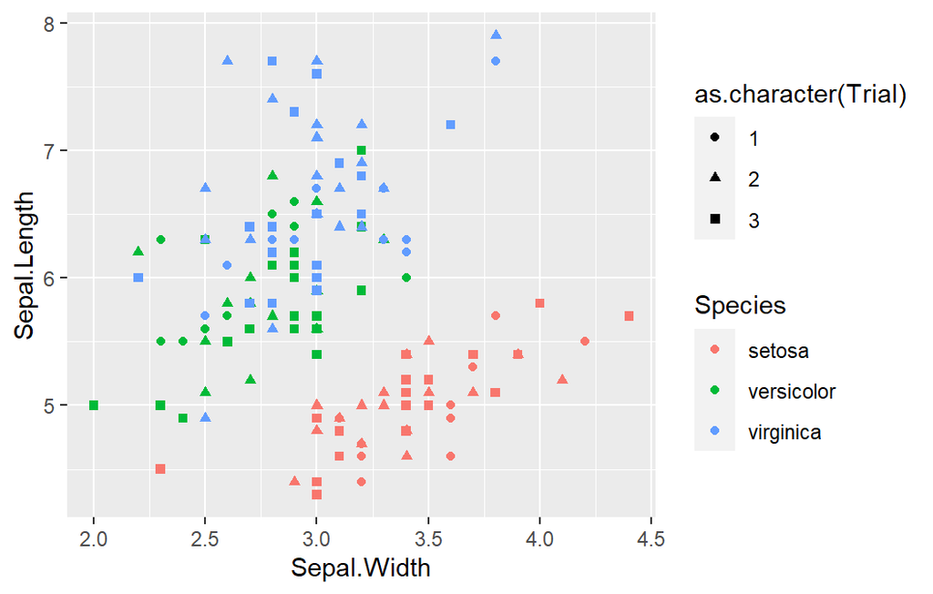

```r
iris_clean %>%
  ggplot(.,aes(x = Sepal.Width, y = Sepal.Length, color = Species,
               shape = as.character(Trial))) +
  geom_point()
```

##### - Let’s try a barchart with x and y coordinates, mapped to species.

##### - The default for geom_barchart(…) is count (similiar to geom_histogram(…)).

##### - What happens if we remove stat = ‘identity’?

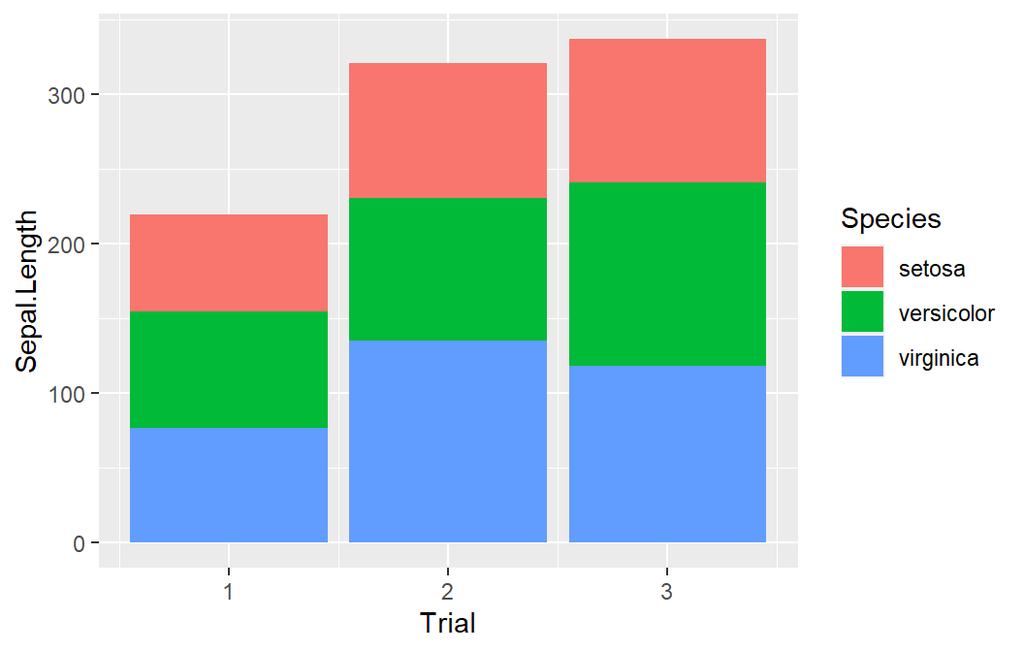

```r
iris_clean %>%
  ggplot(.,aes(x = Trial, y = Sepal.Length, fill = Species)) +
  geom_bar(stat = 'identity')
```

##### - geom_col(…) is the geometry for x and y barcharts.

##### - The default here is stat = ‘identity’, so no need to specify.

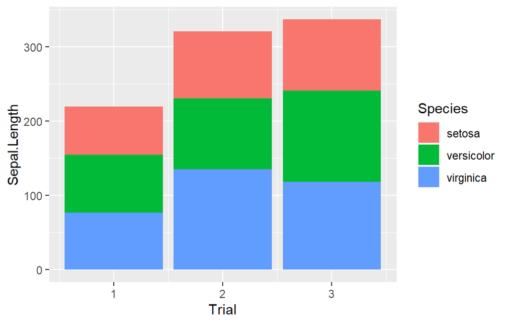

```r
iris_clean %>%
  ggplot(.,aes(x = Trial, y = Sepal.Length, fill = Species)) +
  geom_col()
```

##### - By changing position from the default ‘stacked’ to dodge we can look at the

##### species as separate columns.

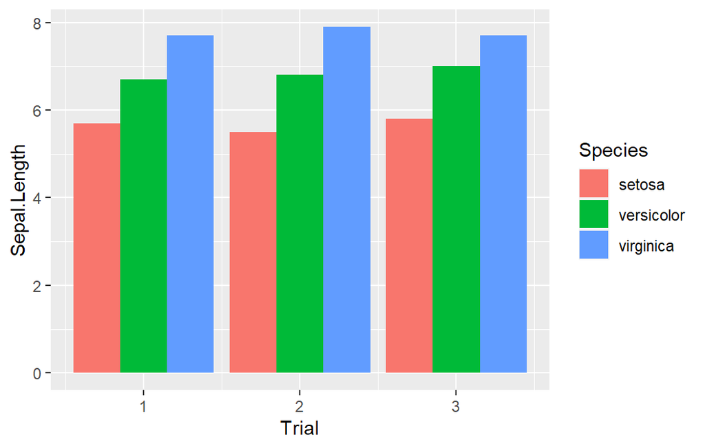

```r
iris_clean %>%
  ggplot(.,aes(x = Trial, y = Sepal.Length, fill = Species)) +
  geom_col(position = 'dodge')
```

##### - Before we move on to the next layer, is there another geom_* you want to try?

##### - Add your own geom_* below from some that we’ve discussed (boxplot, violin?)

##### - What have we learned about default arguments that could help here

##### - Remember to run ’?geom_*()’ to find defaults.

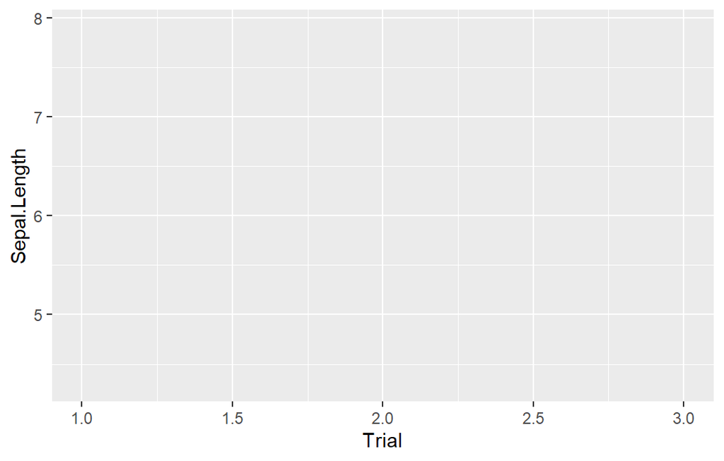

```r
iris_clean %>%
  ggplot(.,aes(x = Trial, y = Sepal.Length, fill = Species))
```

## 6. Scales

#### scale_y_continuous(…), scale_x_discrete(…), scale_color_manual(…), scale_color_brewer(…)

##### - Let’s adjust the breaks in the y axis for each major break.

##### - The data are continuous so we use scale_y_continouus(…).

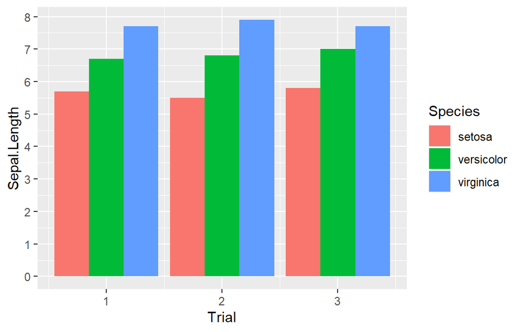

```r
iris_clean %>%
  ggplot(.,aes(x = Trial, y = Sepal.Length, fill = Species)) +
  geom_col(position = 'dodge') +
  scale_y_continuous(breaks = c(0,1,2,3,4,5,6,7,8))
```

##### - Let’s also expand the x-axis so the data fills the plotting area.

##### - Remember, at this point the Trial data is still datatype continuous,

##### - So we use: scale_x_continuous(…)

##### - What happens if we use scale_x_discrete(…)

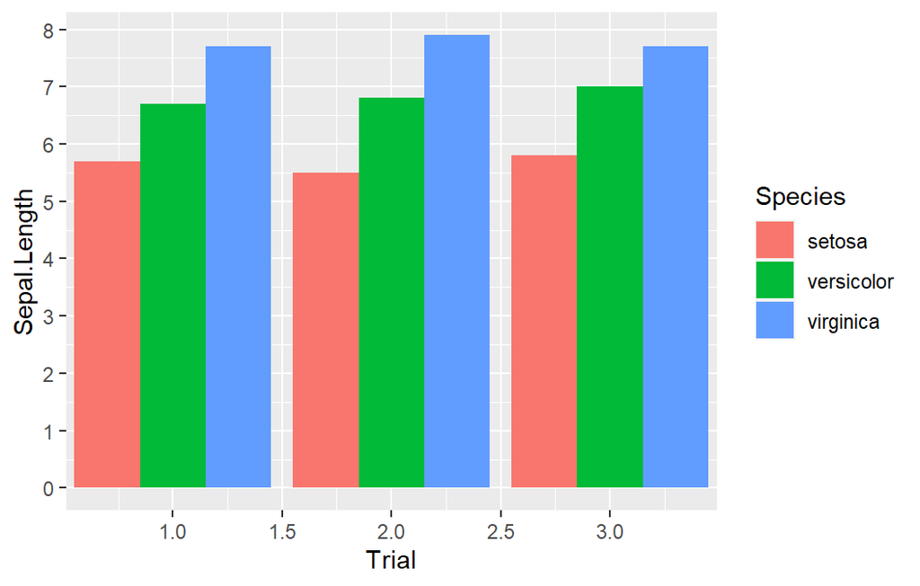

```r
iris_clean %>%
  ggplot(.,aes(x = Trial, y = Sepal.Length, fill = Species)) +
  geom_col(position = 'dodge') +
  scale_y_continuous(breaks = c(0,1,2,3,4,5,6,7,8)) +
  scale_x_continuous(expand = c(0.01,0.01))
```

##### - Want to apply scales to some other attributes?

##### - Lets add another layer of geom below and adjust that.

##### - what are some other things we could do to improve this? (keep in mind for later)

##### - What happens if we change the order of the geoms_*(…)?

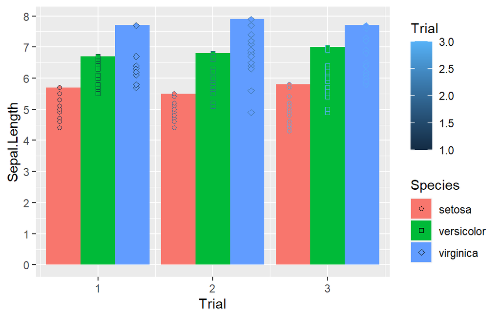

```r
iris_clean %>%
  ggplot(.,aes(x = Trial, y = Sepal.Length, fill = Species)) +
  geom_col(position = 'dodge') +
  geom_point(aes(shape = Species, color = Trial), position = position_dodge(width = 1))+
  scale_y_continuous(breaks = c(0,1,2,3,4,5,6,7,8)) +
  scale_x_continuous(expand = c(0.01,0.01)) +
  scale_shape_manual(values = c(21,22,23))
```

##### - Time to adjust the default colors.

##### - First let’s take a look at the basic Rcolors

```r
colors()
```

[output not shown]

[output cut: 204 more lines]

##### - First we’ll try to manually set our selected colors with scale_color_manual(…)

##### - That changed something, but what?

##### - What’s going on with our data that Trial is continuous

##### - and it didn’t use the colors argument?

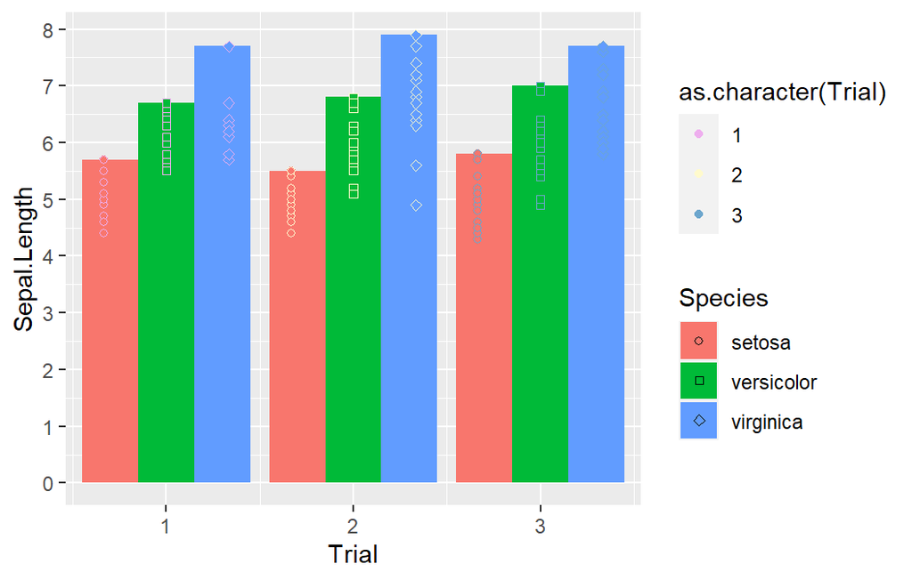

```r
iris_clean %>%
  ggplot(.,aes(x = Trial, y = Sepal.Length, fill = Species)) +
  geom_col(position = 'dodge') +
  geom_point(aes(shape = Species, color = as.character(Trial)), position = position_dodge(width = 1))+
  scale_y_continuous(breaks = c(0,1,2,3,4,5,6,7,8)) +
  scale_x_continuous(expand = c(0.01,0.01)) +
  scale_shape_manual(values = c(21,22,23)) +
  scale_color_manual(values = c('plum2', 'lemonchiffon', 'skyblue3'))
```

##### - Then, we’ll wrap Trial in as.character, add a scale_color_manual(…)

##### - Why are we using both fill and color scales here? (hint: think back to

##### - geom_histogram(…))

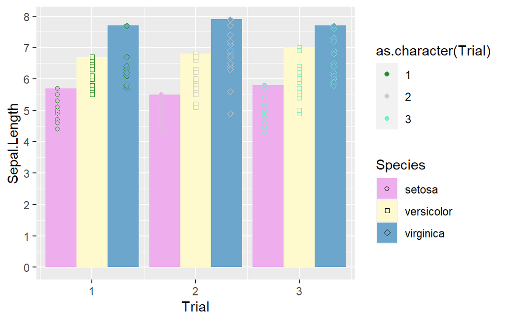

```r
iris_clean %>%
  ggplot(.,aes(x = Trial, y = Sepal.Length, fill = Species)) +
  geom_col(position = 'dodge') +
  geom_point(aes(shape = Species, color = as.character(Trial)),
             position =position_dodge(width = 1))+
  scale_y_continuous(breaks = c(0,1,2,3,4,5,6,7,8)) +
  scale_x_continuous(expand = c(0.01,0.01)) +
  scale_shape_manual(values = c(21,22,23)) +
  scale_fill_manual(values = c('plum2', 'lemonchiffon', 'skyblue3'))+
  scale_color_manual(values = c('forestgreen', 'grey80', 'aquamarine2'))
```

#### What do some of the Pre-Built color scales look like?

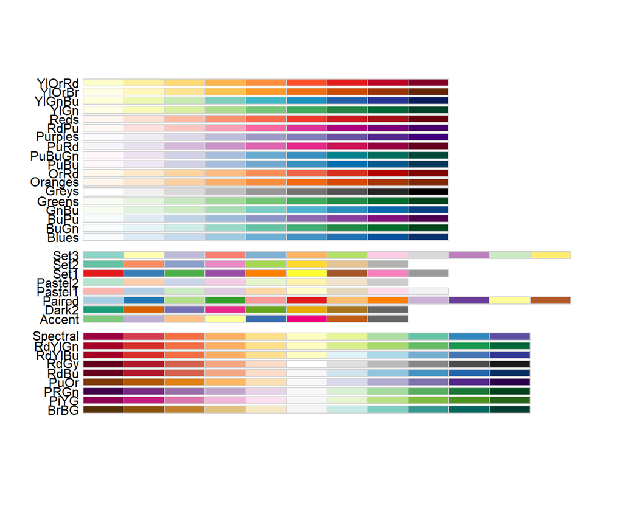

```r
display.brewer.all()
```

##### - Let’s take RcolorBrewer for a spin

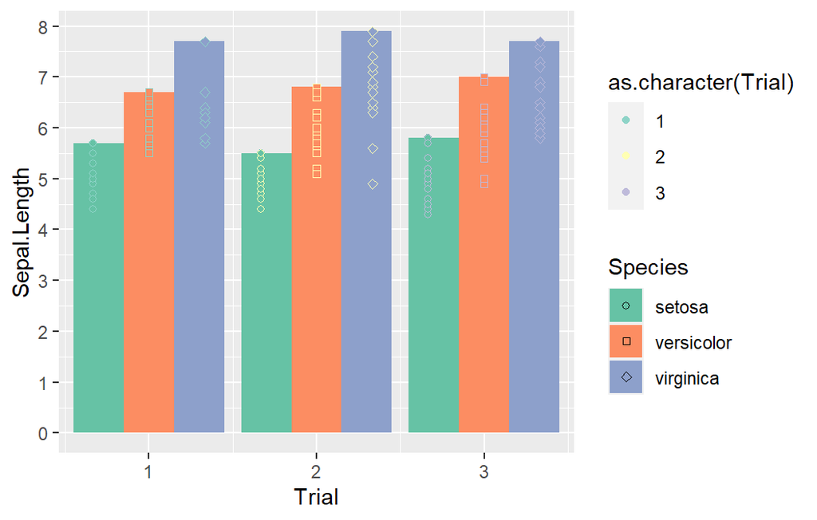

```r
iris_clean %>%
  ggplot(.,aes(x = Trial, y = Sepal.Length, fill = Species)) +
  geom_col(position = 'dodge') +
  geom_point(aes(shape = Species, color = as.character(Trial)), position = position_dodge(width = 1))+
  scale_y_continuous(breaks = c(0,1,2,3,4,5,6,7,8)) +
  scale_x_continuous(expand = c(0.01,0.01)) +
  scale_shape_manual(values = c(21,22,23)) +
  scale_fill_brewer(palette = 'Set2') +
  scale_color_brewer(palette = 'Set3')
```

## 7. Facets

#### facet_wrap(…), facet_grid(…)

##### - Start off with facet_wrap(…) by Trial.

##### - What happens with the x-axis?

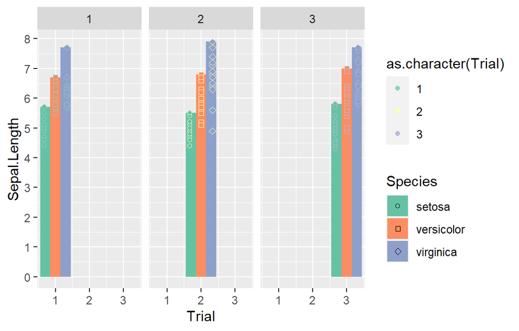

```r
iris_clean %>%
  ggplot(.,aes(x = Trial, y = Sepal.Length, fill = Species)) +
  geom_col(position = 'dodge') +
  geom_point(aes(shape = Species, color = as.character(Trial)), position = position_dodge(width = 1))+
  scale_y_continuous(breaks = c(0,1,2,3,4,5,6,7,8)) +
  scale_x_continuous(expand = c(0.01,0.01)) +
  scale_shape_manual(values = c(21,22,23)) +
  scale_fill_brewer(palette = 'Set2') +
  scale_color_brewer(palette = 'Set3') +
  facet_wrap(~Trial)
```

##### - Adjust the x-axis scale

##### - Lets view by rows instead of columns and move the facet labels

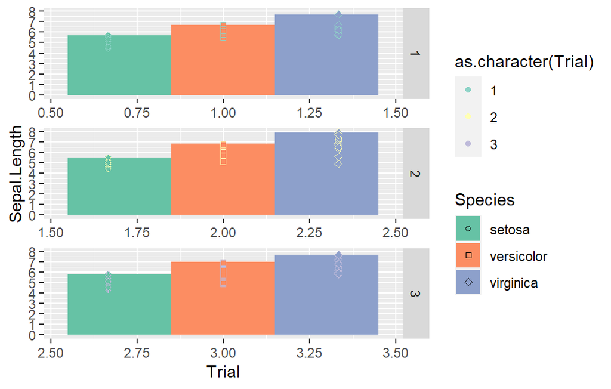

```r
iris_clean %>%
  ggplot(.,aes(x = Trial, y = Sepal.Length, fill = Species)) +
  geom_col(position = 'dodge') +
  geom_point(aes(shape = Species, color = as.character(Trial)), position = position_dodge(width = 1))+
  scale_y_continuous(breaks = c(0,1,2,3,4,5,6,7,8)) +
  scale_x_continuous(expand = c(0.01,0.01)) +
  scale_shape_manual(values = c(21,22,23)) +
  scale_fill_brewer(palette = 'Set2') +
  scale_color_brewer(palette = 'Set3') +
  facet_wrap(~Trial, scales = "free_x", nrow = 3, strip.position = 'right')
```

##### - Facet_grid(…) is similiar, is there any varaible that we should look at

##### - Adjust the code below and add another varaible to the before the ‘~’, what happens?

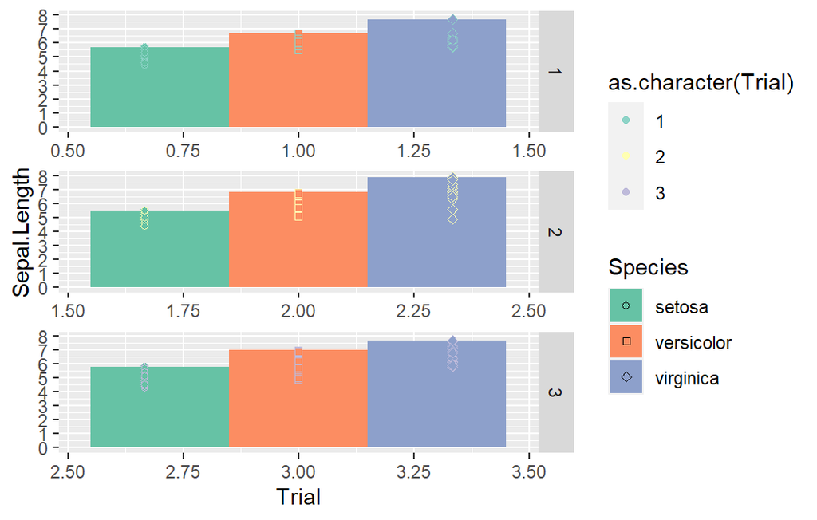

```r
iris_clean %>%
  ggplot(.,aes(x = Trial, y = Sepal.Length, fill = Species)) +
  geom_col(position = 'dodge') +
  geom_point(aes(shape = Species, color = as.character(Trial)), position = position_dodge(width = 1))+
  scale_y_continuous(breaks = c(0,1,2,3,4,5,6,7,8)) +
  scale_x_continuous(expand = c(0.01,0.01)) +
  scale_shape_manual(values = c(21,22,23)) +
  scale_fill_brewer(palette = 'Set2') +
  scale_color_brewer(palette = 'Set3') +
  facet_wrap(~Trial, scales = "free_x", nrow = 3, strip.position = 'right')
```

## 8. Themes

##### - Start by adding some Pre-Built themes.

##### - What other Pre-Built themes are availble, start typing ‘theme’ in the console below.

##### - What pops up? What are their defaults?

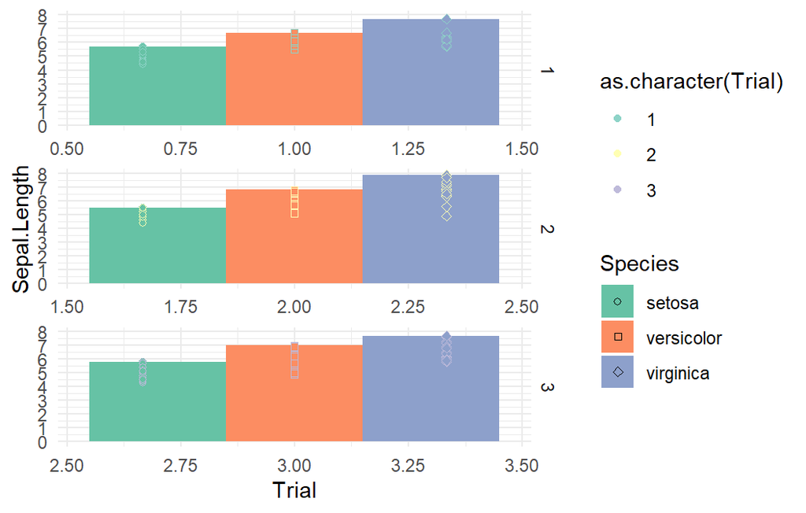

```r
iris_clean %>%
  ggplot(.,aes(x = Trial, y = Sepal.Length, fill = Species)) +
  geom_col(position = 'dodge') +
  geom_point(aes(shape = Species, color = as.character(Trial)), position = position_dodge(width = 1))+
  scale_y_continuous(breaks = c(0,1,2,3,4,5,6,7,8)) +
  scale_x_continuous(expand = c(0.01,0.01)) +
  scale_shape_manual(values = c(21,22,23)) +
  scale_fill_brewer(palette = 'Set2') +
  scale_color_brewer(palette = 'Set3') +
  facet_wrap(~Trial, scales = "free_x", nrow = 3, strip.position = 'right') +
  theme_minimal()
```

##### - Let’s try out setting some of the elements ourselves.

##### - What else would you adjust?

```r
iris_clean %>%
  ggplot(.,aes(x = Trial, y = Sepal.Length, fill = Species)) +
  geom_col(position = 'dodge') +
  geom_point(aes(shape = Species, color = as.character(Trial)), position = position_dodge(width = 1))+
  scale_y_continuous(breaks = c(0,1,2,3,4,5,6,7,8)) +
  scale_x_continuous(expand = c(0.01,0.01)) +
  scale_shape_manual(values = c(21,22,23)) +
  scale_fill_brewer(palette = 'Set2') +
  scale_color_brewer(palette = 'Set3') +
  facet_wrap(~Trial, scales = "free_x", nrow = 3, strip.position = 'right')+
  theme(legend.text = element_text(face = 'bold'),
        text = element_text(family = 'mono', color = 'grey7', size = 10),
        panel.grid.major = element_blank(),
                panel.grid.minor = element_blank(),
                panel.background = element_blank(),
                axis.line = element_line(colour = 'grey10'))
```

[output not shown]

## From Sketch to Story, your turn:

#### Challenge(No Hints)

-Facetted Width and Length

-Bargraph

-Trial axis breaks as ‘2010’, 2015’, ‘2020’

-Ditch the points, and accompanying scale

-Choose a different palette for species

-Dodge position

-Species in italics

-No grey in facet

-Use a more elegant font

```r
iris_clean %>%
  ggplot(.,aes(x = Trial, y = Sepal.Length, fill = Species)) +
  geom_col(position = 'dodge') +
  geom_point(aes(shape = Species, color = as.character(Trial)), position = position_dodge(width = 1))+
  scale_y_continuous(breaks = c(0,1,2,3,4,5,6,7,8)) +
  scale_x_continuous(expand = c(0.01,0.01)) +
  scale_shape_manual(values = c(21,22,23)) +
  scale_fill_brewer(palette = 'Set2') +
  scale_color_brewer(palette = 'Set3') +
  facet_wrap(~Trial, scales = "free_x", nrow = 3, strip.position = 'right')+
  theme(legend.text = element_text(face = 'bold'),
        text = element_text(family = 'mono', color = 'grey7', size = 10),
        panel.grid.major = element_blank(),
                panel.grid.minor = element_blank(),
                panel.background = element_blank(),
                axis.line = element_line(colour = 'grey10'))
```

#### Challenge(Hints)

-Faceted Width and Length - add a tidyr::pivot_longer(…) pipe before ggplot2::

-Bargraph - choose the best option from the geoms we covered

-Trial axis breaks as 2010, 2015, 2020 - transform Trial column to character,use scale*

-Ditch the points, and accompanying scale - delete the correct geom_*()

-Choose the correct scale and change color palette - Modify Existing Scale*

-Dodge position - set from in geom*

-Species in italics - modify the theme

-No grey in facet - modify the theme

-Use a more elegant font - modify the theme, solution uses a different package

```r
iris_clean %>% # Faceted Width and Length - add a tidyr::pivot_longer(...) %>%
  #Trial axis breaks as 2010, 2015, 2020 - transform Trial column to character
  # mutate(Trial = as.character(Trial))
  ggplot(.,aes(x = Trial, y = Sepal.Length, fill = Species)) +
  geom_col(position = 'dodge') + # Bargraph and Dodge - choose the best option from the geoms we covered
  geom_point(aes(shape = Species, color = as.character(Trial)), position = position_dodge(width = 1))+ # delete the points geom
  scale_y_continuous(breaks = c(0,1,2,3,4,5,6,7,8)) +
  scale_x_continuous(expand = c(0.01,0.01)) + #Trial axis breaks as 2010, 2015, 2020, change scale*
  scale_shape_manual(values = c(21,22,23)) + # geom_point() scale, delete
  scale_fill_brewer(palette = 'Set2') + #change this palette
  scale_color_brewer(palette = 'Set3') + #delete this scale, was for points
  facet_wrap(~Trial, scales = "free_x", nrow = 3, strip.position = 'right')+
  theme(legend.text = element_text(face = 'bold'), #Species in italics - modify the theme
        text = element_text(family = 'mono', color = 'grey7', size = 10),# Use a more elegant         font - modify the theme,
        #No grey in facet - modify the theme
        panel.grid.major = element_blank(),
                panel.grid.minor = element_blank(),
                panel.background = element_blank(),
                axis.line = element_line(colour = 'grey10'))
```

### Solution

-Facetted Width and Length - add a tidyr::pivot_longer(…) pipe before ggplot2::

-Bargraph - choose the best option from the geoms we covered

-Trial axis breaks as 2010, 2015, 2020 - transform Trial column to character,use scale*

-Ditch the points, and accompanying scale - delete the correct geom_*()

-Choose the correct scale and change color palette - Modify Existing Scale*

-Dodge position - set from in geom*

-Species in italics - modify the theme

-No grey in facet - modify the theme

-Use a more elegant font - modify the theme, solution uses a different package

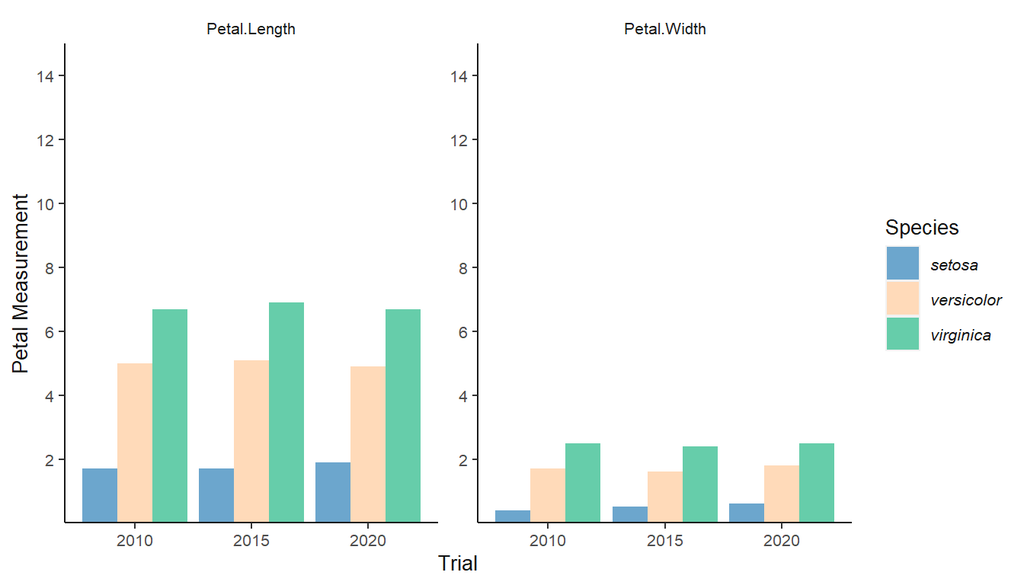

```r
#library(extrafont)
iris_clean %>% tidyr::pivot_longer(cols = c('Petal.Length', 'Petal.Width'),
                                   names_to = 'Petal_Attribute',
                                   values_to = 'Petal_Measurement') %>%
  dplyr::mutate(Trial = as.character(Trial)) %>%
  ggplot(.,aes(x = Trial, y = Petal_Measurement, fill = Species)) +
  geom_col(position = 'dodge') +
  scale_y_continuous(breaks = c(2,4,6,8,10,12,14), expand = c(0,0), limits = c(0, 15)) +
  scale_x_discrete(breaks = c(1,2,3),
                   labels = c('2010', '2015', '2020')) +
  scale_fill_manual(values = c("skyblue3", "peachpuff", 'mediumaquamarine')) +
  scale_color_manual(values = c("skyblue3", "peachpuff", 'mediumaquamarine')) +
  facet_wrap(~Petal_Attribute,
             scales = 'free',
             ncol = 2, strip.position = 'top')+
  theme(legend.text = element_text(face = 'italic'),
        text = element_text(color = 'grey7',
                            size = 10),
                            #family = 'Palatino Linotype'
        strip.background = element_blank(),
        panel.grid.major = element_blank(),
                panel.grid.minor = element_blank(),
                panel.background = element_blank(),
                axis.line = element_line(colour = 'grey10')) +
  ylab('Petal Measurement')
```